# Problem Statement:

- Predicting the impact of tweet that could help Jahanna Chronicle decide if the tweet could go viral or not.
- For some weird reason, Chronicle’s engineering team is adamant that you explore modeling using a decision tree (with some form of boosting and pruning), neural network and linear regression but give the model that fits best.
- To summarize here are the tasks required by Jahanna Chronicle:
- Give the model and code (by uploading it to a public repo) that can best predict the impact score

## Data Set Description

### VARIABLE NAMES: DESCRIPTION

#### There are 15 features and 1 dependent variable (also called as the output variable; Here it is named as ‘impact’).

- **Post Content** - The text in the tweet
- **Sentiment score** - Ranges from -20 to +20 (0 - neutral)
- **Post Length** - The length of the tweet
- **Hashtag Count** - The number of hashtags used in the tweet
- **Content URL Count** - The number of URLs mentioned in the tweet
- **Tweet Count** - The total number of tweets posted by the author of the tweet
- **Followers Count** - The number of followers of the author of the post
- **Listed Count** - the number of lists the post author is a part of
- **Media Type** - The media type of the post (Text, image, video)
- **Published Datetime** - The published time of the tweet
- **Mentions Count** - The number of user mentions in the tweet
- **Post Author Verified** - 1 if author is a verified user
- **Likes** - Likes received for the tweet
- **Shares** - Retweets received for the tweet
- **Comments** - Number of comments for the tweet

## Import Libraries

```python
import pandas as pd
import numpy as np
import matplotlib.pyplot as plt
import seaborn as sns
from warnings import filterwarnings
filterwarnings('ignore')
from sklearn.model_selection import train_test_split,cross_val_score
from sklearn.linear_model import LinearRegression
from sklearn.tree import DecisionTreeRegressor
from sklearn.ensemble import RandomForestRegressor
from sklearn.metrics import roc_curve, precision_recall_curve, classification_report, confusion_matrix
from sklearn.metrics import recall_score, precision_score, f1_score, accuracy_score, roc_auc_score
```

# Load Dataset

```python
df=pd.read_csv(r'C:\Users\SACHIN\Desktop\Radarr assignment jr.ml\Twitter.csv')
```

```python
df.head() #checking first 5 rows
```

|  | Unnamed: 0 | Id | Post Contet | Sentiment score | Post Length | Hashtag count | Content URL count | Tweet count | Followers count | Listed Count | Media Type | Published DateTime | Mentions Count | Post author verified | Likes | Shares | Comments | Impact |
| --- | --- | --- | --- | --- | --- | --- | --- | --- | --- | --- | --- | --- | --- | --- | --- | --- | --- | --- |
| 0 | 41370 | 6d967b125fcecba6357dbc43f8f380cf2d6d7a51 | Sana all na lang. | 0.0 | 17.0 | 0.0 | 0.0 | 1660.0 | 133.0 | 0 | TEXT | 2021-01-28 12:17:24+00:00 | 0.0 | 0.0 | 0.0 | 0.0 | 0.0 | 0.0 |
| 1 | 27955 | 22dc5f808a8589186767412f39e5c88ae9753d04 | キスマイ玉森裕太「ボス恋」台本の裏話明かす\n\n@TBS_asachan @bosskoi... | 19.3 | 84.0 | 0.0 | 1.0 | 318924.0 | 1428273.0 | 5454 | TEXT | 2021-02-24 06:51:02+00:00 | 0.0 | 1.0 | 10.0 | 1.0 | 0.0 | 110.0 |
| 2 | 38151 | 7f224e66ad757e3066d45947881bcaab91f8e57f | SuperM’s album isn’t even out yet and there’s ... | 0.0 | 78.0 | 0.0 | 0.0 | 39976.0 | 1560.0 | 0 | TEXT | 2020-09-15 01:16:32+00:00 | 0.0 | 0.0 | 0.0 | 0.0 | 0.0 | 0.0 |
| 3 | 13558 | 5acc220e7a337efafc4c847b7f74680ca2515890 | மத்திய அரசின் நலத்திட்டங்களை மக்களுக்கு சென்று... | 0.0 | 284.0 | 2.0 | 0.0 | 8045.0 | 27191.0 | 26 | TEXT | 2021-02-14 03:53:53+00:00 | 0.0 | 1.0 | 460.0 | 219.0 | 4.0 | 6830.0 |
| 4 | 17071 | 863abf834897a06afdc459788b34abeae6298f3a | 【熊本県人吉市】球磨川氾濫後のくま川鉄道の線路被害状況 hamusoku.com/archi... | -20.0 | 80.0 | 0.0 | 1.0 | 210996.0 | 2385.0 | 0 | IMAGE | 2020-07-04 13:06:16+00:00 | 0.0 | 0.0 | 0.0 | 0.0 | 0.0 | 0.0 |

```python
df.shape
```

```
(50000, 18)
```

- There are total 50000 rows and 18 columns in the data.

```python
df.columns
```

```
Index(['Unnamed: 0', 'Id', 'Post Contet', 'Sentiment score', 'Post Length',
       'Hashtag count', 'Content URL count', 'Tweet count', 'Followers count',
       'Listed Count', 'Media Type', 'Published DateTime', 'Mentions Count',
       'Post author verified', 'Likes', 'Shares', 'Comments', 'Impact'],
      dtype='object')
```

```python
df['Unnamed: 0'].nunique()
```

```
27991
```

```python
df['Id'].nunique()
```

```
47512
```

- Unnamed: 0 columns is not giving any information.
- There are 47512 unique IDs.
- Unnamed and Id: these are just identifiers and not useful variables so they can be dropped from our future analysis

```python
df=df.drop(['Unnamed: 0','Id'],axis=1)
df.head()
```

|  | Post Contet | Sentiment score | Post Length | Hashtag count | Content URL count | Tweet count | Followers count | Listed Count | Media Type | Published DateTime | Mentions Count | Post author verified | Likes | Shares | Comments | Impact |
| --- | --- | --- | --- | --- | --- | --- | --- | --- | --- | --- | --- | --- | --- | --- | --- | --- |
| 0 | Sana all na lang. | 0.0 | 17.0 | 0.0 | 0.0 | 1660.0 | 133.0 | 0 | TEXT | 2021-01-28 12:17:24+00:00 | 0.0 | 0.0 | 0.0 | 0.0 | 0.0 | 0.0 |
| 1 | キスマイ玉森裕太「ボス恋」台本の裏話明かす\n\n@TBS_asachan @bosskoi... | 19.3 | 84.0 | 0.0 | 1.0 | 318924.0 | 1428273.0 | 5454 | TEXT | 2021-02-24 06:51:02+00:00 | 0.0 | 1.0 | 10.0 | 1.0 | 0.0 | 110.0 |
| 2 | SuperM’s album isn’t even out yet and there’s ... | 0.0 | 78.0 | 0.0 | 0.0 | 39976.0 | 1560.0 | 0 | TEXT | 2020-09-15 01:16:32+00:00 | 0.0 | 0.0 | 0.0 | 0.0 | 0.0 | 0.0 |
| 3 | மத்திய அரசின் நலத்திட்டங்களை மக்களுக்கு சென்று... | 0.0 | 284.0 | 2.0 | 0.0 | 8045.0 | 27191.0 | 26 | TEXT | 2021-02-14 03:53:53+00:00 | 0.0 | 1.0 | 460.0 | 219.0 | 4.0 | 6830.0 |
| 4 | 【熊本県人吉市】球磨川氾濫後のくま川鉄道の線路被害状況 hamusoku.com/archi... | -20.0 | 80.0 | 0.0 | 1.0 | 210996.0 | 2385.0 | 0 | IMAGE | 2020-07-04 13:06:16+00:00 | 0.0 | 0.0 | 0.0 | 0.0 | 0.0 | 0.0 |

```python
df.describe().T
```

|  | count | mean | std | min | 25% | 50% | 75% | max |
| --- | --- | --- | --- | --- | --- | --- | --- | --- |
| Sentiment score | 50000.0 | 1.068916e+00 | 1.043675e+01 | -20.0 | 0.00 | 0.0 | 0.00 | 20.0 |
| Post Length | 50000.0 | 1.546924e+02 | 7.909941e+01 | 1.0 | 94.00 | 142.0 | 215.00 | 373.0 |
| Hashtag count | 50000.0 | 6.875200e-01 | 1.346979e+00 | 0.0 | 0.00 | 0.0 | 1.00 | 21.0 |
| Content URL count | 50000.0 | 4.802600e-01 | 5.260189e-01 | 0.0 | 0.00 | 0.0 | 1.00 | 7.0 |
| Tweet count | 50000.0 | 2.414257e+05 | 1.607467e+06 | 0.0 | 11237.75 | 52738.0 | 259501.50 | 50444081.0 |
| Followers count | 50000.0 | 4.648759e+06 | 1.254513e+07 | 0.0 | 10539.00 | 355122.5 | 2809978.25 | 114440557.0 |
| Listed Count | 50000.0 | 1.006968e+04 | 2.838496e+04 | 0.0 | 2.00 | 555.5 | 6171.00 | 568139.0 |
| Mentions Count | 50000.0 | 1.137200e-01 | 5.129844e-01 | 0.0 | 0.00 | 0.0 | 0.00 | 12.0 |
| Post author verified | 50000.0 | 6.264800e-01 | 4.837432e-01 | 0.0 | 0.00 | 1.0 | 1.00 | 1.0 |
| Likes | 50000.0 | 3.020706e+03 | 8.261945e+03 | 0.0 | 1.00 | 153.0 | 1909.00 | 90919.0 |
| Shares | 50000.0 | 9.667733e+02 | 3.117213e+03 | 0.0 | 0.00 | 42.0 | 559.00 | 79671.0 |
| Comments | 50000.0 | 1.640792e+01 | 5.436693e+02 | 0.0 | 0.00 | 0.0 | 0.00 | 66939.0 |
| Impact | 50000.0 | 4.003874e+04 | 1.030758e+05 | 0.0 | 10.00 | 2100.0 | 27500.00 | 997980.0 |

```python
#Checking data types of each variable
df.dtypes
```

```
Post Contet              object
Sentiment score         float64
Post Length             float64
Hashtag count           float64
Content URL count       float64
Tweet count             float64
Followers count         float64
Listed Count              int64
Media Type               object
Published DateTime       object
Mentions Count          float64
Post author verified    float64
Likes                   float64
Shares                  float64
Comments                float64
Impact                  float64
dtype: object
```

```python
df.isnull().sum()
```

```
Post Contet             0
Sentiment score         0
Post Length             0
Hashtag count           0
Content URL count       0
Tweet count             0
Followers count         0
Listed Count            0
Media Type              0
Published DateTime      0
Mentions Count          0
Post author verified    0
Likes                   0
Shares                  0
Comments                0
Impact                  0
dtype: int64
```

- No missing values in the data

```python
numerical=df.select_dtypes(include=np.number)
```

```python
numerical=df.select_dtypes(include=np.number)
numerical_columns = df.select_dtypes(include=np.number).columns
numerical_columns
```

```
Index(['Sentiment score', 'Post Length', 'Hashtag count', 'Content URL count',
       'Tweet count', 'Followers count', 'Listed Count', 'Mentions Count',
       'Post author verified', 'Likes', 'Shares', 'Comments', 'Impact'],
      dtype='object')
```

```python
categorical_columns = df.select_dtypes(exclude=np.number).columns
print('We have', len(categorical_columns), 'categorical variables that are', list(categorical_columns))
print('We have', len(numerical_columns), 'numerical variables that are', list(numerical_columns))
```

```
We have 3 categorical variables that are ['Post Contet', 'Media Type', 'Published DateTime']
We have 13 numerical variables that are ['Sentiment score', 'Post Length', 'Hashtag count', 'Content URL count', 'Tweet count', 'Followers count', 'Listed Count', 'Mentions Count', 'Post author verified', 'Likes', 'Shares', 'Comments', 'Impact']
```

```python
df.columns
```

```
Index(['Post Contet', 'Sentiment score', 'Post Length', 'Hashtag count',
       'Content URL count', 'Tweet count', 'Followers count', 'Listed Count',
       'Media Type', 'Published DateTime', 'Mentions Count',
       'Post author verified', 'Likes', 'Shares', 'Comments', 'Impact'],
      dtype='object')
```

### Checking skewness

```
Sentiment score
0.0633600820518989
```

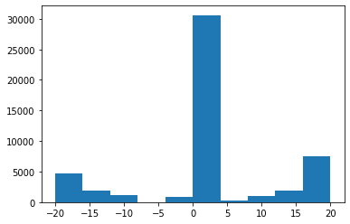

```
Post Length
0.306659871809087
```

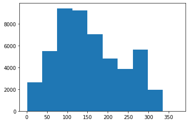

```
Hashtag count
3.478723510252165
```

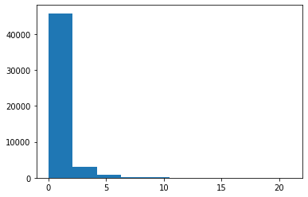

```
Content URL count
0.5021233861911586
```

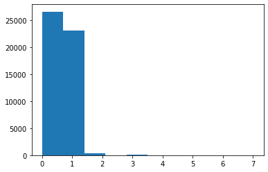

```
Tweet count
28.4319149253793
```

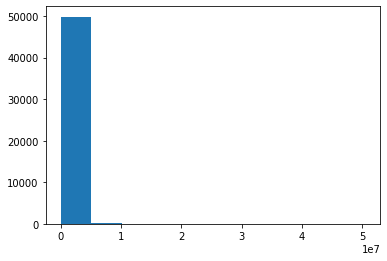

```
Followers count
4.3586956041123885
```

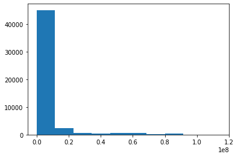

```
Listed Count
6.216534603148287
```

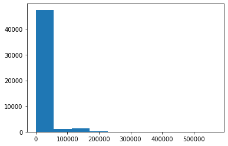

```
Mentions Count
8.382496585808378
```

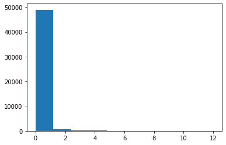

```
Post author verified
-0.5229429901063717
```

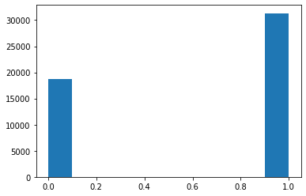

```
Likes
5.130681574826555
```

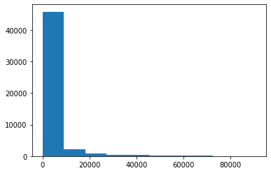

```
Shares
8.163343369447427
```

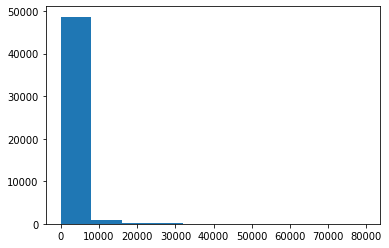

```
Comments
84.83757082013946
```

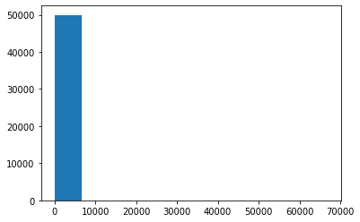

```
Impact
4.697916571383966
```

[1 more figures not shown]

```python
for i in numerical.columns:
    print(i)
    plt.hist(df[i])
    print(df[i].skew())
    plt.show()
```

- Data is highly skewed we can perform transformation later on

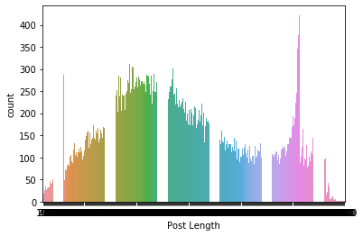

```python
sns.countplot(df['Post Length'])
plt.show()
```

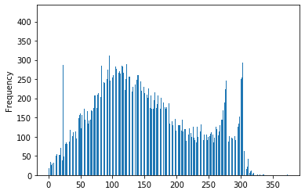

```python
df['Post Length'].plot(bins=600, kind='hist')
plt.show()
```

```python
print(df['Post Length'].min()) #checking post length
print(df['Post Length'].max())
```

```
1.0
373.0
```

```python
df['Impact'].value_counts()
```

```
0.0         10026
10.0         3448
20.0         1708
30.0         1019
40.0          647
            ...
213200.0        1
80670.0         1
28990.0         1
103300.0        1
37790.0         1
Name: Impact, Length: 10809, dtype: int64
```

```python
df['Impact'].nunique()
```

```
10809
```

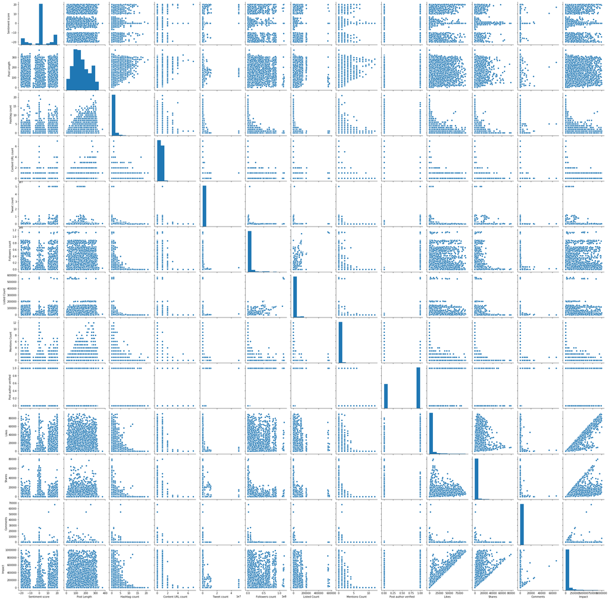

```python
sns.pairplot(df)
```

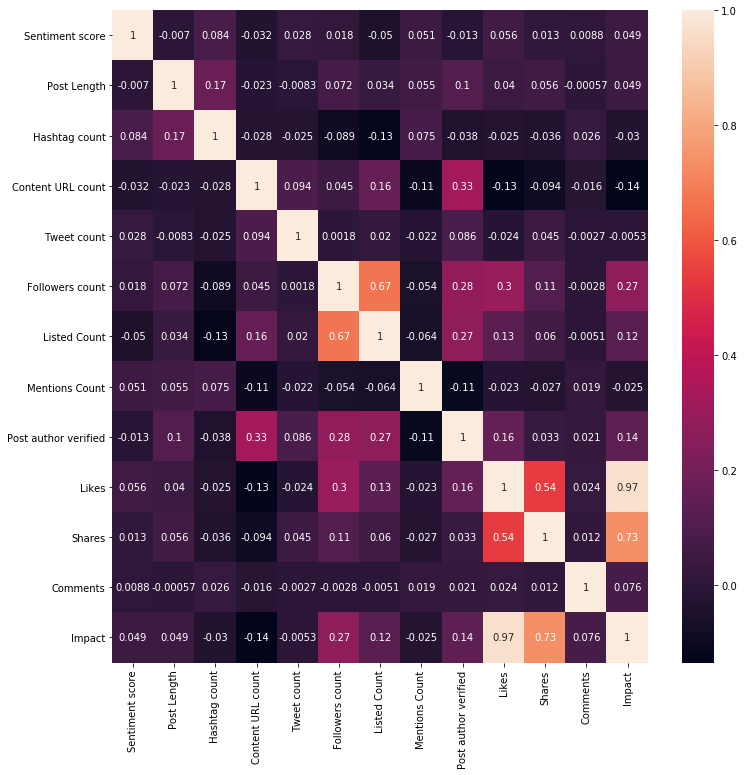

```python
plt.figure(figsize=(12,12))
sns.heatmap(df.corr(),annot=True)
plt.show()
```

- According to the heatmap it shows that columns : Likes and shares are highly correlated to the Impact which means these columns are playing major role to Predicting the tweet could go viral or not.

```python
df['Sentiment score'].value_counts()
```

```
 0.00     29083
 20.00     1724
 1.33       835
 19.99      497
-1.33       438
          ...
-0.52         1
-14.88        1
 3.73         1
 11.29        1
 3.93         1
Name: Sentiment score, Length: 2100, dtype: int64
```

```python
df['Sentiment score'].nunique()
```

```
2100
```

```python
df['Hashtag count'].value_counts()
```

```
0.0     32984
1.0      9017
2.0      3763
3.0      2066
4.0      1005
5.0       522
6.0       251
7.0       143
8.0        86
9.0        50
10.0       36
11.0       28
12.0       13
14.0       11
13.0        8
15.0        7
16.0        4
17.0        3
18.0        1
21.0        1
19.0        1
Name: Hashtag count, dtype: int64
```

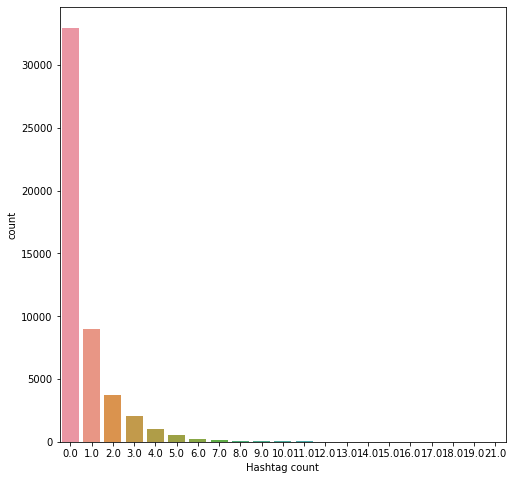

```python
plt.figure(figsize=(8,8))
sns.countplot(df['Hashtag count'])
```

- According to the plot most of the users disnt use hastags and their total counts were 32984
- Around 9000 users have used single hashtag
- Max hashtags used in a tweet are 21

```python
df['Content URL count'].value_counts()
```

```
0.0    26542
1.0    22988
2.0      411
3.0       40
4.0       15
5.0        2
7.0        1
6.0        1
Name: Content URL count, dtype: int64
```

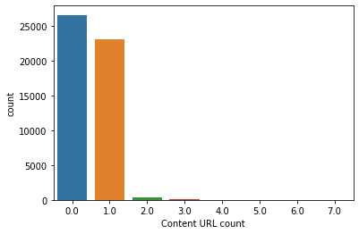

```python
sns.countplot(df['Content URL count'])
plt.show()
```

- According to the countplot approx half of the users (22,988) have been shared link in their tweets.

```python
df['Tweet count'].value_counts()
```

```
38344.0      33
1.0          24
3.0          24
2.0          23
38509.0      22
             ..
38470.0       1
2305174.0     1
184899.0      1
464379.0      1
79335.0       1
Name: Tweet count, Length: 39328, dtype: int64
```

```python
df['Tweet count'].nunique()
```

```
39328
```

```python
df['Followers count'].max()
```

```
114440557.0
```

- Highest followers : 114440557

```python
df.columns
```

```
Index(['Post Contet', 'Sentiment score', 'Post Length', 'Hashtag count',
       'Content URL count', 'Tweet count', 'Followers count', 'Listed Count',
       'Media Type', 'Published DateTime', 'Mentions Count',
       'Post author verified', 'Likes', 'Shares', 'Comments', 'Impact'],
      dtype='object')
```

```python
df['Media Type'].value_counts()
```

```
TEXT     30176
IMAGE    17426
VIDEO     2398
Name: Media Type, dtype: int64
```

- Here 3 types of media categories : Text, Image, Video

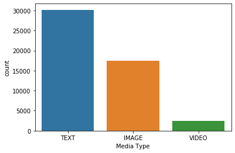

```python
sns.countplot(df['Media Type'])
plt.show()
```

- We can clearly see that 30,176 out of 50,000 tweets are in text format
- Many users have shared Images conent as well which are 17,426 and video content counts are 2,398

### Encoding

```python
df.dtypes
```

```
Post Contet              object
Sentiment score         float64
Post Length             float64
Hashtag count           float64
Content URL count       float64
Tweet count             float64
Followers count         float64
Listed Count              int64
Media Type               object
Published DateTime       object
Mentions Count          float64
Post author verified    float64
Likes                   float64
Shares                  float64
Comments                float64
Impact                  float64
dtype: object
```

- The original dataset used string values for Media type. To better fit this variable into our model, we interpret the variable to numeric binary variables to reflect their nature.
- We have done one hot encoding

```python
media_dummies = pd.get_dummies(df['Media Type'],drop_first=True)
media_dummies.head()
```

|  | TEXT | VIDEO |
| --- | --- | --- |
| 0 | 1 | 0 |
| 1 | 1 | 0 |
| 2 | 1 | 0 |
| 3 | 1 | 0 |
| 4 | 0 | 0 |

```python
df = pd.concat([df,media_dummies], axis=1)
df.drop(['Media Type'], inplace=True, axis=1)
df.head()
```

|  | Post Contet | Sentiment score | Post Length | Hashtag count | Content URL count | Tweet count | Followers count | Listed Count | Published DateTime | Mentions Count | Post author verified | Likes | Shares | Comments | Impact | TEXT | VIDEO |
| --- | --- | --- | --- | --- | --- | --- | --- | --- | --- | --- | --- | --- | --- | --- | --- | --- | --- |
| 0 | Sana all na lang. | 0.0 | 17.0 | 0.0 | 0.0 | 1660.0 | 133.0 | 0 | 2021-01-28 12:17:24+00:00 | 0.0 | 0.0 | 0.0 | 0.0 | 0.0 | 0.0 | 1 | 0 |
| 1 | キスマイ玉森裕太「ボス恋」台本の裏話明かす\n\n@TBS_asachan @bosskoi... | 19.3 | 84.0 | 0.0 | 1.0 | 318924.0 | 1428273.0 | 5454 | 2021-02-24 06:51:02+00:00 | 0.0 | 1.0 | 10.0 | 1.0 | 0.0 | 110.0 | 1 | 0 |
| 2 | SuperM’s album isn’t even out yet and there’s ... | 0.0 | 78.0 | 0.0 | 0.0 | 39976.0 | 1560.0 | 0 | 2020-09-15 01:16:32+00:00 | 0.0 | 0.0 | 0.0 | 0.0 | 0.0 | 0.0 | 1 | 0 |
| 3 | மத்திய அரசின் நலத்திட்டங்களை மக்களுக்கு சென்று... | 0.0 | 284.0 | 2.0 | 0.0 | 8045.0 | 27191.0 | 26 | 2021-02-14 03:53:53+00:00 | 0.0 | 1.0 | 460.0 | 219.0 | 4.0 | 6830.0 | 1 | 0 |
| 4 | 【熊本県人吉市】球磨川氾濫後のくま川鉄道の線路被害状況 hamusoku.com/archi... | -20.0 | 80.0 | 0.0 | 1.0 | 210996.0 | 2385.0 | 0 | 2020-07-04 13:06:16+00:00 | 0.0 | 0.0 | 0.0 | 0.0 | 0.0 | 0.0 | 0 | 0 |

```python
df['Published DateTime'].nunique()
```

```
47412
```

```python
df["Published DateTime"]= pd.to_datetime(df["Published DateTime"]) #converting datatype from object to date
```

```python
df['Published DateTime'].head()
```

```
0   2021-01-28 12:17:24+00:00
1   2021-02-24 06:51:02+00:00
2   2020-09-15 01:16:32+00:00
3   2021-02-14 03:53:53+00:00
4   2020-07-04 13:06:16+00:00
Name: Published DateTime, dtype: datetime64[ns, UTC]
```

```python
df['Published DateTime']=df["Published DateTime"].astype('object')
```

```python
df2=df.copy()
```

```python
df2.drop(['Post Contet',"Published DateTime"],axis=1,inplace=True)
```

```python
df2.dtypes
```

```
Sentiment score         float64
Post Length             float64
Hashtag count           float64
Content URL count       float64
Tweet count             float64
Followers count         float64
Listed Count              int64
Mentions Count          float64
Post author verified    float64
Likes                   float64
Shares                  float64
Comments                float64
Impact                  float64
TEXT                      uint8
VIDEO                     uint8
dtype: object
```

```python
df['Mentions Count'].value_counts()
```

```
0.0     46238
1.0      2716
2.0       658
3.0       199
4.0        81
5.0        33
6.0        32
7.0        13
8.0         8
9.0         8
10.0        8
11.0        3
12.0        3
Name: Mentions Count, dtype: int64
```

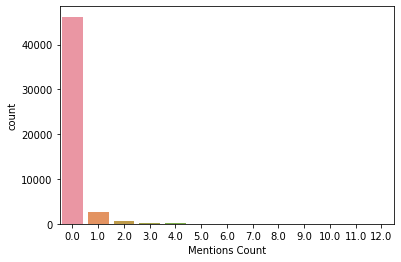

```python
sns.countplot(df['Mentions Count'])
```

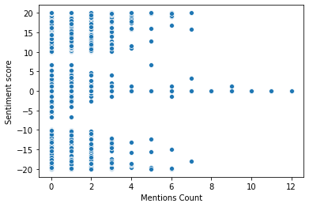

```python
sns.scatterplot(df['Mentions Count'],df['Sentiment score'])
```

```python
df['Post author verified'].value_counts()
```

```
1.0    31324
0.0    18676
Name: Post author verified, dtype: int64
```

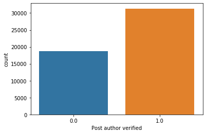

```python
sns.countplot(df['Post author verified'])
```

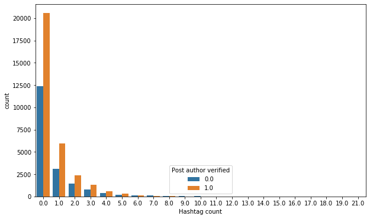

```python
plt.figure(figsize=(10,6))
sns.countplot(df['Hashtag count'],hue=df['Post author verified'])
plt.show()
```

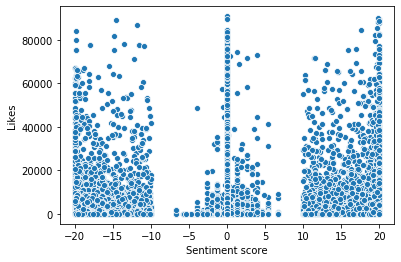

```python
sns.scatterplot(df['Sentiment score'],df['Likes'])
```

- According to the scatterplot we can see that the Sentiment score range between 10 to 20, -20 to -10 and 0 have highest number of likes might be these are the posts which have the higher chances to get viral

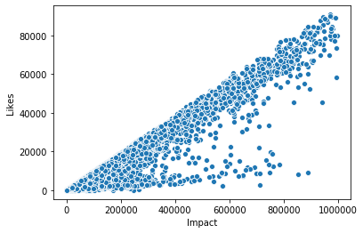

```python
sns.scatterplot(df['Impact'],df['Likes'])
```

- As the number of likes increased the impact values are also increased
- This shows very strong relationship between Likes and impact

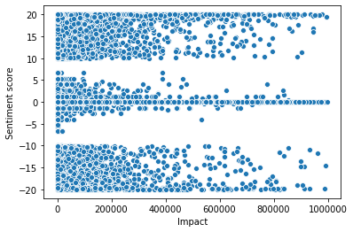

```python
sns.scatterplot(df['Impact'],df['Sentiment score'])
```

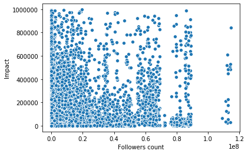

```python
sns.scatterplot(df['Followers count'],df['Impact'])
```

- Impact values are not dependent on followers

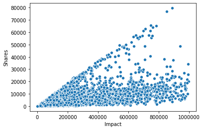

```python
sns.scatterplot(df['Impact'],df['Shares'])
```

- Shares also have the higher contribution in impact values

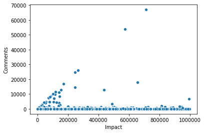

```python
sns.scatterplot(df['Impact'],df['Comments'])
```

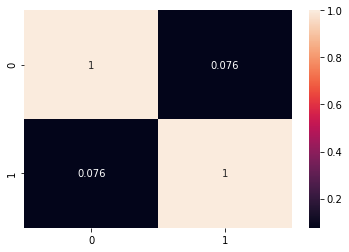

```python
sns.heatmap(np.corrcoef(df['Impact'],df['Comments']),annot=True)
plt.show()
```

- Comments dont have contribution in Impact values and they have very less correlation between them